# Statistical Modeling and Sensitivity Analysis

Artificial Protein Intake and Acute Kidney Injury | SUSTAIN CSX

19 November 2026

# 1 1. Research Objective

## 1.1 Research Question

Is artificially administered protein intake during ICU days 1–4 associated with AKI after day 4, after adjustment for preoperative risk and surgical complexity?

Artificial protein intake was not randomized. The analysis therefore estimates an observational association rather than a causal treatment effect.

## 1.2 Outcomes and Covariates

| Role | Variable | Interpretation |
| --- | --- | --- |
| Exposure | `Protein_intake__d1_4` | Mean artificial protein intake, g/kg/day |
| Primary outcome | `AKI_any` | New AKI after day 4 |
| Secondary outcome | `AKI_any_early` | New AKI on days 5–6 |
| Sensitivity outcome | `AKI_any_sensitivity_worst_case` | Worst-case handling of ICU death |
| Core covariate | `EuroScore2` | Preoperative surgical risk |
| Core covariate | CPB duration | Intraoperative exposure |
| Additional covariate | `BMI` | Preoperative patient characteristic |
| Exploratory covariate | Oral-feeding days | Feeding status during days 1–4 |

The primary model uses continuous artificial protein intake, EuroSCORE II and CPB duration.

Protein associations are reported per 0.1 g/kg/day; CPB associations per 30 minutes.

# 2 2. Analysis Population

## 2.1 2.1 Available Observations

Study population and AKI events

| Patients | Primary_events | Secondary_events | Worst_case_events |
| --- | --- | --- | --- |
| 293 | 74 | 31 | 89 |

## 2.2 2.2 Complete Cases for the Core Model

Both primary development models use the same complete-case sample.

Primary model analysis sample

| Measure | Value |
| --- | --- |
| Total eligible patients | 293 |
| Complete cases | 291 |
| Excluded due to missing core model variables | 2 |
| AKI events | 74 |
| Non-AKI patients | 217 |
| AKI proportion (%) | 25.4 |

# 3 3. Training and Test Sets

## 3.1 3.1 Stratified Split

We randomly allocate approximately 80% of patients to training and 20% to testing, stratified by primary AKI status.

Stratification maintains representation of both AKI and non-AKI patients in each subset.

The test set is not used for model fitting or cross-validation.

Stratified training and test sets

| Sample | Patients | AKI_events | Non_AKI |
| --- | --- | --- | --- |
| Training | 232 | 59 | 173 |
| Testing | 59 | 15 | 44 |

The split is used for evaluating prediction performance. It is not necessary for unbiased estimation of a prespecified observational regression association.

# 4 4. Model Development on Training Data

## 4.1 4.1 Unadjusted Logistic Regression

```
## [1] TRUE
```

Unadjusted logistic regression: training sample

| Variable | Estimate | SE | OR | CI_lower | CI_upper | p_value |
| --- | --- | --- | --- | --- | --- | --- |
| Protein_01 | 0.1304553 | 0.0509334 | 1.139 | 1.031 | 1.259 | 0.0104 |

## 4.2 4.2 Core Adjusted Logistic Regression

```
## [1] TRUE
```

Adjusted logistic regression: training sample

| Variable | Estimate | SE | OR | CI_lower | CI_upper | p_value |
| --- | --- | --- | --- | --- | --- | --- |
| Protein_01 | 0.1149816 | 0.0525447 | 1.122 | 1.012 | 1.244 | 0.0287 |
| EuroScore2 | 0.0124479 | 0.0141585 | 1.013 | 0.985 | 1.041 | 0.3790 |
| CPB_30 | 0.0548266 | 0.0655348 | 1.056 | 0.929 | 1.201 | 0.4030 |

## 4.3 4.3 Protein Association Comparison

Protein association in training models

| Model | OR | CI_lower | CI_upper | p_value |
| --- | --- | --- | --- | --- |
| Unadjusted | 1.139 | 1.031 | 1.259 | 0.0104 |
| Adjusted: EuroSCORE II + CPB | 1.122 | 1.012 | 1.244 | 0.0287 |

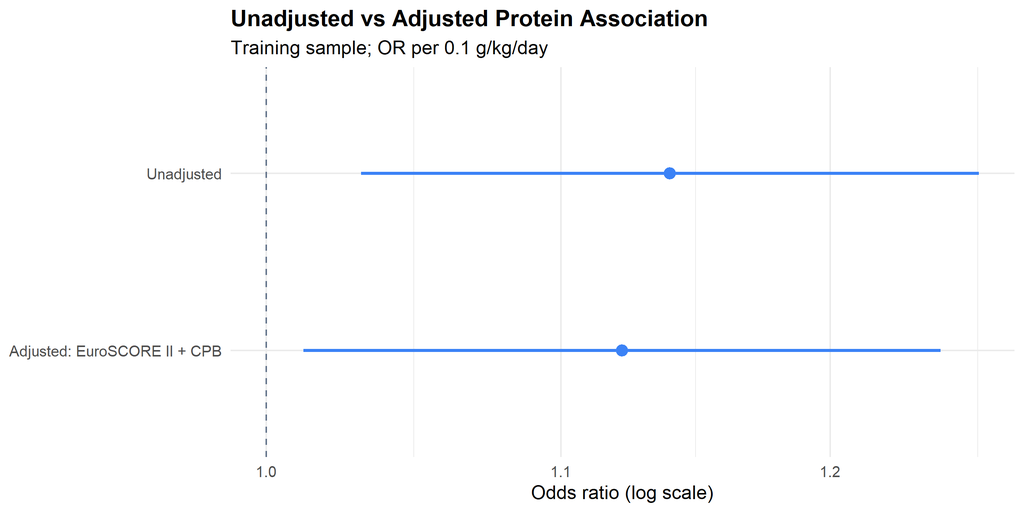

The estimated change between models may partly reflect measured risk differences. Changes in logistic-regression odds ratios cannot be attributed entirely to confounding because odds ratios are non-collapsible.

# 5 5. Cross-Validation

## 5.1 5.1 Stratified K-Fold Cross-Validation

Cross-validation evaluates how well the predefined model performs on patients excluded from each fold’s model fitting.

For each fold:

1. Fit the model using the remaining training folds.
2. Predict AKI probabilities for the excluded fold.
3. Collect the out-of-fold predictions.
4. Calculate performance metrics.

The held-out test set remains untouched throughout this process.

5-fold cross-validation performance

| Model | Patients | AKI_events | AUC | Brier | Log_loss |
| --- | --- | --- | --- | --- | --- |
| Unadjusted | 232 | 59 | 0.647 | 0.186 | 0.556 |
| Core adjusted | 232 | 59 | 0.558 | 0.195 | 0.577 |

AUC measures discrimination. The Brier score measures the mean squared error of predicted probabilities, and log loss penalizes incorrect confident predictions.

For AUC, higher is better; for Brier score and log loss, lower is better.

These metrics assess prediction, not whether the protein coefficient has a causal interpretation.

## 5.2 5.2 Cross-Validated Calibration

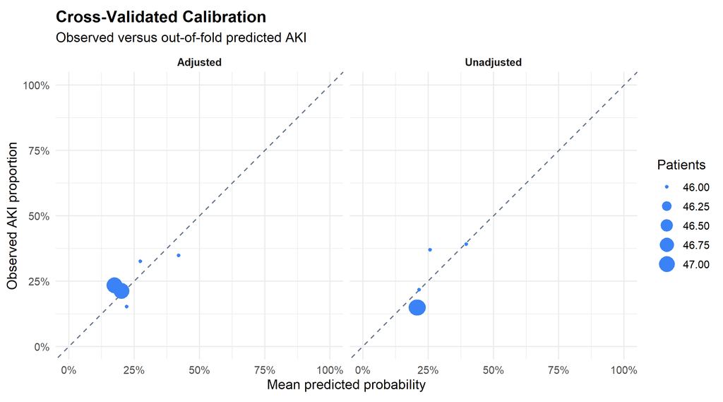

With limited events, individual calibration bins can contain few AKI cases. This plot is exploratory and should not be interpreted as a precise calibration assessment.

# 6 6. Held-Out Test-Set Evaluation

Both training models are applied to patients who were excluded from model development and cross-validation.

No test-set observations are used to refit either model.

Performance on the held-out test set

| Model | Patients | AKI_events | AUC | Brier | Log_loss |
| --- | --- | --- | --- | --- | --- |
| Unadjusted | 59 | 15 | 0.641 | 0.183 | 0.551 |
| Core adjusted | 59 | 15 | 0.686 | 0.175 | 0.531 |

## 6.1 6.1 Cross-Validation versus Test Performance

Internal validation performance comparison

| Evaluation | Model | Patients | AKI_events | AUC | Brier | Log_loss |
| --- | --- | --- | --- | --- | --- | --- |
| Cross-validation | Unadjusted | 232 | 59 | 0.647 | 0.186 | 0.556 |
| Cross-validation | Core adjusted | 232 | 59 | 0.558 | 0.195 | 0.577 |
| Test set | Unadjusted | 59 | 15 | 0.641 | 0.183 | 0.551 |
| Test set | Core adjusted | 59 | 15 | 0.686 | 0.175 | 0.531 |

Test performance may be unstable if the test set is small. A favorable result on one random split is not sufficient to establish external validity.

# 7 7. Final Primary Association Analysis

For the scientific association analysis, we now refit the prespecified models using **all complete cases**.

This improves precision compared with reporting coefficients from the training subset alone.

The following models are intended for inference about the observed protein–AKI association, not as independent test-set predictions.

## 7.1 7.1 Final Unadjusted and Adjusted Models

```
## [1] TRUE
```

```
## [1] TRUE
```

Final protein association using all complete cases

| Model | OR | CI_lower | CI_upper | p_value |
| --- | --- | --- | --- | --- |
| Unadjusted | 1.142 | 1.044 | 1.250 | 0.00369 |
| Core adjusted | 1.110 | 1.009 | 1.221 | 0.03250 |

Final adjusted regression coefficients

| Variable | Estimate | SE | OR | CI_lower | CI_upper | p_value |
| --- | --- | --- | --- | --- | --- | --- |
| Protein_01 | 0.1039754 | 0.0486228 | 1.110 | 1.009 | 1.221 | 0.0325 |
| EuroScore2 | 0.0196841 | 0.0132076 | 1.020 | 0.994 | 1.047 | 0.1360 |
| CPB_30 | 0.0719242 | 0.0571438 | 1.075 | 0.961 | 1.202 | 0.2080 |

## 7.2 7.2 Observed Outcomes and Adjusted Fitted Curve

Blue points represent patients without AKI and red points represent patients with AKI.

The black curve shows the model-estimated AKI probability, standardized over the observed EuroSCORE II and CPB duration distributions.

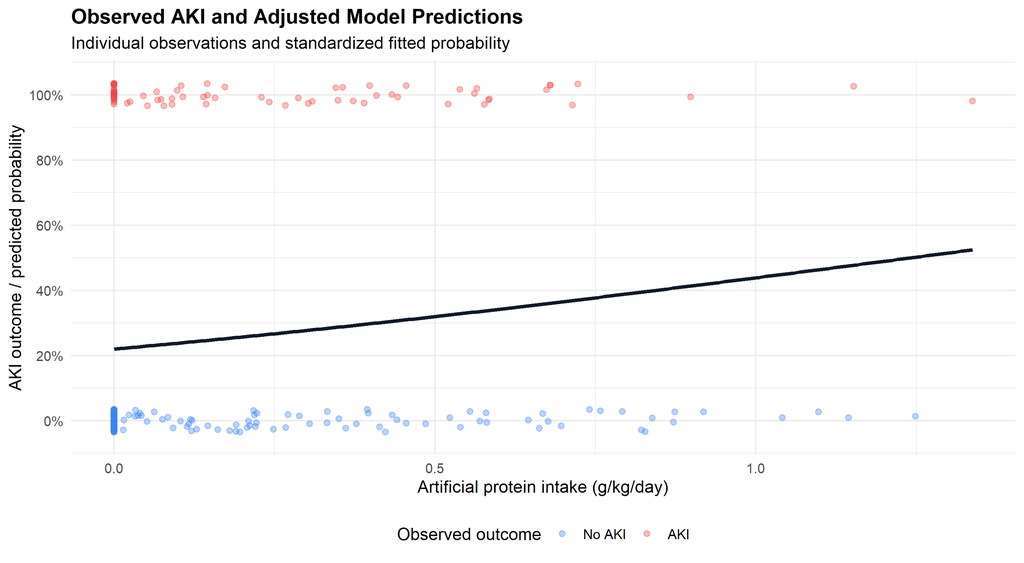

The fitted curve is not an observed risk curve or a causal dose-response estimate. Predictions at protein doses with poor covariate overlap require particular caution.

# 8 8. Model Diagnostics

The following diagnostics examine residual behavior, predictive calibration, leverage and influential observations.

Because AKI is binary, logistic regression does not require normally distributed residuals.

## 8.1 8.1 Four Diagnostic Plots

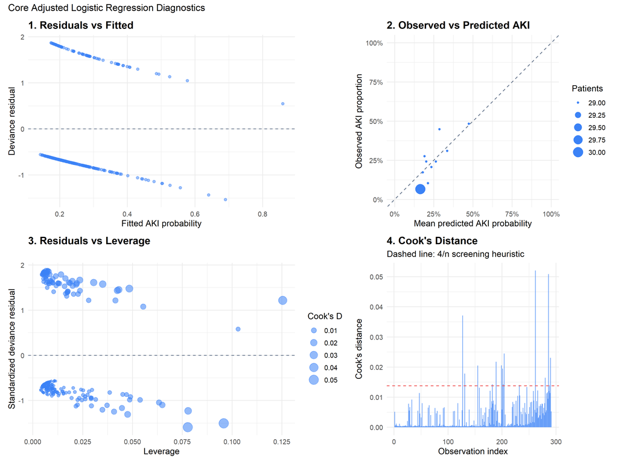

## 8.2 8.2 Diagnostic Summary

Influence diagnostic summary

| Patients | Maximum_Cooks_D | Above_4_over_n | Maximum_leverage |
| --- | --- | --- | --- |
| 291 | 0.052 | 15 | 0.1254 |

Observations with high influence require investigation, not automatic removal. The plots do not establish the absence of confounding or validate every model assumption.

## 8.3 8.3 Exploratory Nonlinearity Assessment

A logistic regression assumes linearity of continuous predictors on the log-odds scale.

We investigate whether a more flexible protein relationship is supported by the data. This comparison is exploratory.

Exploratory comparison of linear and spline protein effects

| Resid. Df | Resid. Dev | Df | Deviance | Pr(>Chi) |
| --- | --- | --- | --- | --- |
| 287 | 317.081 | NA | NA | NA |
| 285 | 301.411 | 2 | 15.671 | 0 |

# 9 9. Additional Covariate Analyses

## 9.1 9.1 BMI Adjustment

```
##
##
## Sample: 291 patients; 74 AKI events.
```

## 9.2 9.2 Exploratory Oral-Feeding Adjustment

Oral feeding was measured concurrently with artificial protein intake. It may reflect evolving illness and recovery rather than a conventional pre-exposure confounder.

Consequently, this model is exploratory and does not necessarily provide a less biased estimate.

Exposure overlap by oral-feeding days

| Oral_days | Protein_group | Patients |
| --- | --- | --- |
| 0 | Zero | 10 |
| 0 | Positive | 95 |
| 1 | Zero | 1 |
| 1 | Positive | 12 |
| 2 | Zero | 16 |
| 2 | Positive | 12 |
| 3 | Zero | 37 |
| 3 | Positive | 8 |
| 4 | Zero | 100 |
| 4 | Positive | 0 |

Exploratory oral-feeding adjustment

| Model | OR | CI_lower | CI_upper | p_value |
| --- | --- | --- | --- | --- |
| Core model | 1.110 | 1.009 | 1.221 | 0.0325 |
| Core model + oral feeding | 0.971 | 0.860 | 1.097 | 0.6370 |

# 10 10. Secondary and Worst-Case Outcome Analyses

## 10.1 10.1 Outcome Validation

Before comparing outcomes, we verify consistency between the secondary indicator and primary AKI.

AKI outcome consistency

| Check | Patients |
| --- | --- |
| Day 5-6 AKI without primary AKI | 0 |

The after-day-6 exploratory outcome is not modeled here because its validity depends on confirming that the day 5–6 indicator represents the first occurrence of new AKI.

## 10.2 10.2 Worst-Case Classification Check

Primary versus worst-case AKI classification

| AKI_primary | AKI_worst | Patients |
| --- | --- | --- |
| 0 | 0 | 204 |
| 0 | 1 | 15 |
| 1 | 1 | 74 |

ICU death among reclassified patients

| Death_status | Patients |
| --- | --- |
| Died in ICU | 15 |

The worst-case indicator comes directly from the supplied dataset. Patients reclassified as AKI cases are not necessarily patients with documented kidney injury.

## 10.3 10.3 Adjusted Models Across Outcomes

The three outcome models use a common complete-case sample for comparability.

```
## [1] TRUE
```

```
## [1] TRUE
```

```
## [1] TRUE
```

Adjusted protein association across AKI outcomes

| Model | OR | CI_lower | CI_upper | p_value | Patients | AKI_events |
| --- | --- | --- | --- | --- | --- | --- |
| Primary: AKI after day 4 | 1.110 | 1.009 | 1.221 | 0.0325 | 291 | 74 |
| Secondary: AKI days 5-6 | 1.092 | 0.962 | 1.240 | 0.1710 | 291 | 31 |
| Worst-case AKI | 1.195 | 1.085 | 1.316 | 0.0003 | 291 | 89 |

## 10.4 10.4 Outcome Comparison Forest Plot

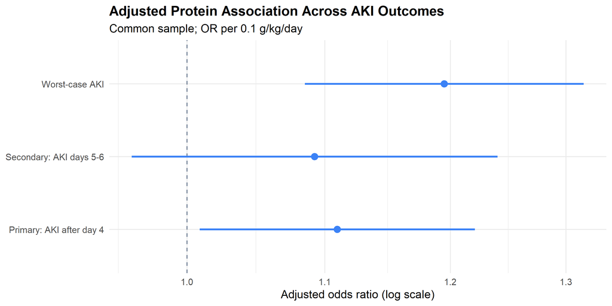

These models examine associations under different endpoint definitions. Their coefficients should not be interpreted as direct estimates of the causal effect of artificial protein intake.

# 11 11. Discussion and Limitations

## 11.1 Interpretation Framework

The analysis should address:

1. The magnitude, direction and uncertainty of the primary protein association.
2. Differences between unadjusted and adjusted models.
3. Cross-validated and held-out predictive performance.
4. Whether the model specification is supported by diagnostic results.
5. The sensitivity of the association to BMI, oral feeding, and AKI definitions.

## 11.2 Important Limitations

**Confounding by indication:** Artificial protein was prescribed according to clinical judgment rather than randomized.

**Residual confounding:** EuroSCORE II and CPB duration do not fully capture postoperative ICU severity.

**Selection bias:** The cohort consists of patients with prolonged ICU stays, potentially selected according to severity and complications.

**Limited exposure overlap:** Patients with four exclusively oral-feeding days received no artificially administered protein.

**Competing events:** ICU death can prevent subsequent AKI from being observed. Worst-case classification examines one assumption but does not resolve the competing-risk problem.

**Internal validation:** Cross-validation and a test split describe predictive performance. Neither removes confounding nor validates causal interpretations.

**Sample size:** The precision of all models depends on the numbers of events and non-events, especially within training, validation, and test subsets.

## 11.3 Conclusion

The primary adjusted regression estimates the association between artificial protein intake and subsequent AKI, conditional on EuroSCORE II and CPB duration.

Cross-validation and held-out testing provide additional information about predictive performance. The final association models use all complete cases to avoid unnecessarily sacrificing statistical precision.

Interpretation should prioritize effect sizes, confidence intervals, model adequacy, clinical plausibility and the limitations of the observational design.

# 12 References

1. Stoppe C, et al. (2023). *Effect of High-Dose Selenium on Postoperative Organ Dysfunction and Mortality in Cardiac Surgery Patients.* JAMA Surgery. https://doi.org/10.1001/jamasurg.2022.6855
2. Project proposal (2026). *Acute kidney injury after major cardiac surgery: the association with protein intake in the acute phase.*
3. Project partner’s written responses on eligibility, artificial nutrition and mortality sensitivity analysis.
4. Steyerberg EW, Harrell FE. (2016). *Prediction models need appropriate internal, internal-external, and external validation.* Journal of Clinical Epidemiology.
5. Steyerberg EW. (2018). *Validation in prediction research: the waste by data splitting.* Journal of Clinical Epidemiology. https://pubmed.ncbi.nlm.nih.gov/30063954/
6. Riley RD, et al. (2019). *Minimum sample size for developing a multivariable prediction model: Part II—binary and time-to-event outcomes.* Statistics in Medicine. https://doi.org/10.1002/sim.7992
7. Hernán MA, Robins JM. *Causal Inference: What If.* https://www.hsph.harvard.edu/miguel-hernan/causal-inference-book/

*All clinical data are processed locally. AI-generated code and interpretations require critical review and documentation according to course requirements.*